# Analyzing [Ford GoBike System](https://s3.amazonaws.com/fordgobike-data/index.html) Data

By : Dushyant Bhatia  
July 2020

- Introduction
- 1. Gathering Data
- 2. Assessing Data
- 3. Cleaning Data
- 4. Univariate Exploration
- 5. Bivariate Exploration
- 6. Multivariate Exploration

### Introduction

Ford GoBike is a regional public bicycle sharing system in the San Francisco Bay Area, California. Beginning operation in August 2013 as Bay Area Bike Share, the Ford GoBike system currently has over 2,600 bicycles in 262 stations across San Francisco, East Bay and San Jose. On June 28, 2017, the system officially launched as Ford GoBike in a partnership with Ford Motor Company.  
Ford GoBike, like other bike share systems, consists of a fleet of specially designed, sturdy and durable bikes that are locked into a network of docking stations throughout the city. The bikes can be unlocked from one station and returned to any other station in the system, making them ideal for one-way trips. The bikes are available for use 24 hours/day, 7 days/week, 365 days/year and riders have access to all bikes in the network when they become a member or purchase a pass.

### Preliminary Wrangling

- This document starts by following the basic data exploration rules such as Data Gathering, Assesing, Cleaning and then move on to the exploratory visuals.

## 1. Gathering Data

```python
# import required libraries
import numpy as np
import pandas as pd
import matplotlib.pyplot as plt
import seaborn as sns
import missingno as ms
import os
import requests as req
from io import BytesIO
from zipfile import ZipFile

%matplotlib inline
```

```python
# extracting datasets from urls below
urls = ['https://s3.amazonaws.com/fordgobike-data/201801-fordgobike-tripdata.csv.zip',
        'https://s3.amazonaws.com/fordgobike-data/201802-fordgobike-tripdata.csv.zip',
        'https://s3.amazonaws.com/fordgobike-data/201803-fordgobike-tripdata.csv.zip',
        'https://s3.amazonaws.com/fordgobike-data/201804-fordgobike-tripdata.csv.zip',
        'https://s3.amazonaws.com/fordgobike-data/201805-fordgobike-tripdata.csv.zip',
        'https://s3.amazonaws.com/fordgobike-data/201806-fordgobike-tripdata.csv.zip',
        'https://s3.amazonaws.com/fordgobike-data/201807-fordgobike-tripdata.csv.zip',
        'https://s3.amazonaws.com/fordgobike-data/201808-fordgobike-tripdata.csv.zip',
        'https://s3.amazonaws.com/fordgobike-data/201809-fordgobike-tripdata.csv.zip',
        'https://s3.amazonaws.com/fordgobike-data/201810-fordgobike-tripdata.csv.zip',
        'https://s3.amazonaws.com/fordgobike-data/201811-fordgobike-tripdata.csv.zip',
        'https://s3.amazonaws.com/fordgobike-data/201812-fordgobike-tripdata.csv.zip',
        'https://s3.amazonaws.com/fordgobike-data/201901-fordgobike-tripdata.csv.zip',
        'https://s3.amazonaws.com/fordgobike-data/201902-fordgobike-tripdata.csv.zip',
        'https://s3.amazonaws.com/fordgobike-data/201903-fordgobike-tripdata.csv.zip']

for url in urls:
    response = req.get(url)
    zip_file = ZipFile(BytesIO(response.content))
    zip_file.extractall('ford-gobike-trip-data')
```

```python
#concat all the datasets in a single dataframe
path = r'ford-gobike-trip-data'
bike_df = []

for file in os.listdir(path):
    bike_df.append(pd.read_csv(path + '/' + file))

df = pd.concat(bike_df, sort=False)
```

## 2. Assessing Data

```python
df.head()
```

|  | duration_sec | start_time | end_time | start_station_id | start_station_name | start_station_latitude | start_station_longitude | end_station_id | end_station_name | end_station_latitude | end_station_longitude | bike_id | user_type | member_birth_year | member_gender | bike_share_for_all_trip |
| --- | --- | --- | --- | --- | --- | --- | --- | --- | --- | --- | --- | --- | --- | --- | --- | --- |
| 0 | 75284 | 2018-01-31 22:52:35.2390 | 2018-02-01 19:47:19.8240 | 120.0 | Mission Dolores Park | 37.761420 | -122.426435 | 285.0 | Webster St at O'Farrell St | 37.783521 | -122.431158 | 2765 | Subscriber | 1986.0 | Male | No |
| 1 | 85422 | 2018-01-31 16:13:34.3510 | 2018-02-01 15:57:17.3100 | 15.0 | San Francisco Ferry Building (Harry Bridges Pl... | 37.795392 | -122.394203 | 15.0 | San Francisco Ferry Building (Harry Bridges Pl... | 37.795392 | -122.394203 | 2815 | Customer | NaN | NaN | No |
| 2 | 71576 | 2018-01-31 14:23:55.8890 | 2018-02-01 10:16:52.1160 | 304.0 | Jackson St at 5th St | 37.348759 | -121.894798 | 296.0 | 5th St at Virginia St | 37.325998 | -121.877120 | 3039 | Customer | 1996.0 | Male | No |
| 3 | 61076 | 2018-01-31 14:53:23.5620 | 2018-02-01 07:51:20.5000 | 75.0 | Market St at Franklin St | 37.773793 | -122.421239 | 47.0 | 4th St at Harrison St | 37.780955 | -122.399749 | 321 | Customer | NaN | NaN | No |
| 4 | 39966 | 2018-01-31 19:52:24.6670 | 2018-02-01 06:58:31.0530 | 74.0 | Laguna St at Hayes St | 37.776435 | -122.426244 | 19.0 | Post St at Kearny St | 37.788975 | -122.403452 | 617 | Subscriber | 1991.0 | Male | No |

```python
df.info()
```

```
<class 'pandas.core.frame.DataFrame'>
Int64Index: 2495514 entries, 0 to 256298
Data columns (total 16 columns):
duration_sec               int64
start_time                 object
end_time                   object
start_station_id           float64
start_station_name         object
start_station_latitude     float64
start_station_longitude    float64
end_station_id             float64
end_station_name           object
end_station_latitude       float64
end_station_longitude      float64
bike_id                    int64
user_type                  object
member_birth_year          float64
member_gender              object
bike_share_for_all_trip    object
dtypes: float64(7), int64(2), object(7)
memory usage: 323.7+ MB
```

```python
df.describe().round(2)
```

|  | duration_sec | start_station_id | start_station_latitude | start_station_longitude | end_station_id | end_station_latitude | end_station_longitude | bike_id | member_birth_year |
| --- | --- | --- | --- | --- | --- | --- | --- | --- | --- |
| count | 2495514.00 | 2483077.00 | 2495514.00 | 2495514.00 | 2483077.00 | 2495514.00 | 2495514.00 | 2495514.00 | 2355088.00 |
| mean | 834.40 | 124.32 | 37.77 | -122.35 | 122.77 | 37.77 | -122.35 | 2859.17 | 1983.50 |
| std | 2254.83 | 103.97 | 0.10 | 0.15 | 103.96 | 0.10 | 0.15 | 1700.62 | 10.38 |
| min | 61.00 | 3.00 | 37.26 | -122.47 | 3.00 | 37.26 | -122.47 | 11.00 | 1878.00 |
| 25% | 346.00 | 36.00 | 37.77 | -122.41 | 31.00 | 37.77 | -122.41 | 1482.00 | 1978.00 |
| 50% | 549.00 | 90.00 | 37.78 | -122.40 | 90.00 | 37.78 | -122.40 | 2794.00 | 1986.00 |
| 75% | 860.00 | 195.00 | 37.80 | -122.29 | 195.00 | 37.80 | -122.29 | 4011.00 | 1991.00 |
| max | 86366.00 | 407.00 | 45.51 | -73.57 | 407.00 | 45.51 | -73.57 | 7082.00 | 2001.00 |

```python
df['user_type'].value_counts()
```

```
Subscriber    2135153
Customer       360361
Name: user_type, dtype: int64
```

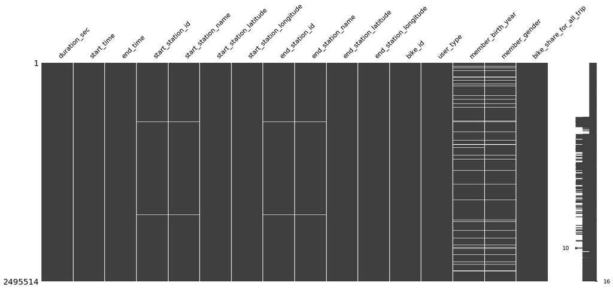

```python
ms.matrix(df);
```

- 6 of the columns have missing values

```python
df.isnull().sum()
```

```
duration_sec                    0
start_time                      0
end_time                        0
start_station_id            12437
start_station_name          12437
start_station_latitude          0
start_station_longitude         0
end_station_id              12437
end_station_name            12437
end_station_latitude            0
end_station_longitude           0
bike_id                         0
user_type                       0
member_birth_year          140426
member_gender              140072
bike_share_for_all_trip         0
dtype: int64
```

## 3. Cleaning Data

```python
df_bike_clean = df.copy()
df_bike_clean.shape
```

```
(2495514, 16)
```

##### Define

Remove missing data

##### Code

```python
df_bike_clean.dropna(inplace=True)
#test
df_bike_clean.shape
```

```
(2342985, 16)
```

##### Define

Change datatypes

**Code**

```python
df_bike_clean.info()
```

```
<class 'pandas.core.frame.DataFrame'>
Int64Index: 2342985 entries, 0 to 256298
Data columns (total 16 columns):
duration_sec               int64
start_time                 object
end_time                   object
start_station_id           float64
start_station_name         object
start_station_latitude     float64
start_station_longitude    float64
end_station_id             float64
end_station_name           object
end_station_latitude       float64
end_station_longitude      float64
bike_id                    int64
user_type                  object
member_birth_year          float64
member_gender              object
bike_share_for_all_trip    object
dtypes: float64(7), int64(2), object(7)
memory usage: 303.9+ MB
```

```python
df_bike_clean=df_bike_clean.astype({'user_type': 'category'
                                   ,'member_gender':'category','bike_share_for_all_trip':'category'})
```

```python
df_bike_clean.start_time = pd.to_datetime(df_bike_clean.start_time)
df_bike_clean.end_time = pd.to_datetime(df_bike_clean.end_time)
```

```python
df_bike_clean=df_bike_clean.astype({'bike_id': 'str'
                                   ,'start_station_id':'str','end_station_id':'str'})
```

**Test**

```python
df_bike_clean.info()
```

```
<class 'pandas.core.frame.DataFrame'>
Int64Index: 2342985 entries, 0 to 256298
Data columns (total 16 columns):
duration_sec               int64
start_time                 datetime64[ns]
end_time                   datetime64[ns]
start_station_id           object
start_station_name         object
start_station_latitude     float64
start_station_longitude    float64
end_station_id             object
end_station_name           object
end_station_latitude       float64
end_station_longitude      float64
bike_id                    object
user_type                  category
member_birth_year          float64
member_gender              category
bike_share_for_all_trip    category
dtypes: category(3), datetime64[ns](2), float64(5), int64(1), object(5)
memory usage: 257.0+ MB
```

**Define**  
Adding granularity to the time data

**Code**

```python
# add column day of the week from start time
df_bike_clean['day_of_the_week']=df_bike_clean['start_time'].dt.strftime('%a')
```

```python
# add column ride hour from start time
df_bike_clean['ride_hour']=df_bike_clean['start_time'].dt.hour
```

**Test**

```python
df_bike_clean.head(2)
```

|  | duration_sec | start_time | end_time | start_station_id | start_station_name | start_station_latitude | start_station_longitude | end_station_id | end_station_name | end_station_latitude | end_station_longitude | bike_id | user_type | member_birth_year | member_gender | bike_share_for_all_trip | day_of_the_week | ride_hour |
| --- | --- | --- | --- | --- | --- | --- | --- | --- | --- | --- | --- | --- | --- | --- | --- | --- | --- | --- |
| 0 | 75284 | 2018-01-31 22:52:35.239 | 2018-02-01 19:47:19.824 | 120.0 | Mission Dolores Park | 37.761420 | -122.426435 | 285.0 | Webster St at O'Farrell St | 37.783521 | -122.431158 | 2765 | Subscriber | 1986.0 | Male | No | Wed | 22 |
| 2 | 71576 | 2018-01-31 14:23:55.889 | 2018-02-01 10:16:52.116 | 304.0 | Jackson St at 5th St | 37.348759 | -121.894798 | 296.0 | 5th St at Virginia St | 37.325998 | -121.877120 | 3039 | Customer | 1996.0 | Male | No | Wed | 14 |

##### Define

Adding a column as `member_age` and removing outliers

##### Code

```python
# calculating the age of member at the time of renting the bike
df_bike_clean['member_age'] = df_bike_clean['start_time'].dt.year.astype(int)-df_bike_clean['member_birth_year']
```

```python
df_bike_clean.member_age.describe(percentiles = [ .95])
```

```
count    2.342985e+06
mean     3.478069e+01
std      1.036658e+01
min      1.800000e+01
50%      3.200000e+01
95%      5.500000e+01
max      1.410000e+02
Name: member_age, dtype: float64
```

```python
# outliers start around age 60
df_bike_clean=df_bike_clean.query('member_age < 60')
```

**Test**

```python
df_bike_clean.head(2)
```

|  | duration_sec | start_time | end_time | start_station_id | start_station_name | start_station_latitude | start_station_longitude | end_station_id | end_station_name | end_station_latitude | end_station_longitude | bike_id | user_type | member_birth_year | member_gender | bike_share_for_all_trip | day_of_the_week | ride_hour | member_age |
| --- | --- | --- | --- | --- | --- | --- | --- | --- | --- | --- | --- | --- | --- | --- | --- | --- | --- | --- | --- |
| 0 | 75284 | 2018-01-31 22:52:35.239 | 2018-02-01 19:47:19.824 | 120.0 | Mission Dolores Park | 37.761420 | -122.426435 | 285.0 | Webster St at O'Farrell St | 37.783521 | -122.431158 | 2765 | Subscriber | 1986.0 | Male | No | Wed | 22 | 32.0 |
| 2 | 71576 | 2018-01-31 14:23:55.889 | 2018-02-01 10:16:52.116 | 304.0 | Jackson St at 5th St | 37.348759 | -121.894798 | 296.0 | 5th St at Virginia St | 37.325998 | -121.877120 | 3039 | Customer | 1996.0 | Male | No | Wed | 14 | 22.0 |

```python
# changing float to int
df_bike_clean=df_bike_clean.astype({'member_age': 'int'
                                   ,'member_birth_year':'int'})
```

```python
df_bike_clean.shape
```

```
(2284482, 19)
```

```python
# seaborn blue color
base_color = sns.color_palette()[0]
```

```python
# save data
# df_bike_clean.to_csv('clean_master_file.csv', index=False)
```

```python
columns = ['start_station_id', 'start_station_latitude', 'start_station_longitude','end_station_id', 'end_station_latitude', 'end_station_longitude']

df_bike_clean.drop(columns = columns, inplace = True)
```

### What is/are the main feature(s) of interest in your dataset?

- Bike ride durations
- Age group of the customers
- Most busy days
- User type

## 4. Univariate Exploration

```python
df_bike_clean.head(2)
```

|  | duration_sec | start_time | end_time | start_station_name | end_station_name | bike_id | user_type | member_birth_year | member_gender | bike_share_for_all_trip | day_of_the_week | ride_hour | member_age |
| --- | --- | --- | --- | --- | --- | --- | --- | --- | --- | --- | --- | --- | --- |
| 0 | 75284 | 2018-01-31 22:52:35.239 | 2018-02-01 19:47:19.824 | Mission Dolores Park | Webster St at O'Farrell St | 2765 | Subscriber | 1986 | Male | No | Wed | 22 | 32 |
| 2 | 71576 | 2018-01-31 14:23:55.889 | 2018-02-01 10:16:52.116 | Jackson St at 5th St | 5th St at Virginia St | 3039 | Customer | 1996 | Male | No | Wed | 14 | 22 |

#### Number of rides distributed among duration

```python
# functions with a user defined parameter
def limit_x(x):
    return plt.xlim(0,x)
def limit_y(y):
    return plt.ylim(0,y)
def figure_size(h):
    return plt.figure(figsize = [h, 5])
```

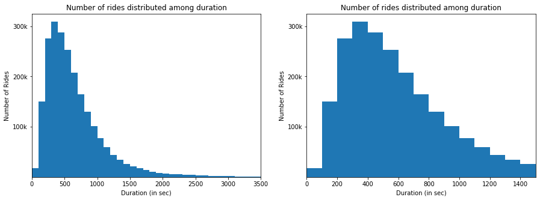

```python
figure_size(15)
# histogram on left, example of too-large bin size
plt.subplot(1, 2, 1) # 1 row, 2 cols, subplot 1
bin_edges = np.arange(0, df_bike_clean['duration_sec'].max()+100, 100)
plt.hist(data = df_bike_clean, x = 'duration_sec', bins = bin_edges)
limit_x(3500)
plt.xlabel("Duration (in sec)")
plt.ylabel("Number of Rides")
plt.yticks([100000, 200000, 300000], ['100k','200k', '300k'])
plt.title("Number of rides distributed among duration")

# histogram on right, example of too-small bin size
plt.subplot(1, 2, 2) # 1 row, 2 cols, subplot 2
bin_edges = np.arange(0, df_bike_clean['duration_sec'].max()+100, 100)
plt.hist(data = df_bike_clean, x = 'duration_sec', bins = bin_edges)
limit_x(1500)
plt.xlabel("Duration (in sec)")
plt.ylabel("Number of Rides")
plt.yticks([100000, 200000, 300000], ['100k','200k', '300k'])

plt.title("Number of rides distributed among duration");
```

- First histogram shows that the data is very highly skewed
- Hence, for a better visual distribution in second histogram duration_sec max value is limited to 1500
- Majority of the rides lie between 200 - 700 second range (4-11 minutes)

#### weekday usege of the bike sharing system

```python
df_try = df_bike_clean.sample(1000)
```

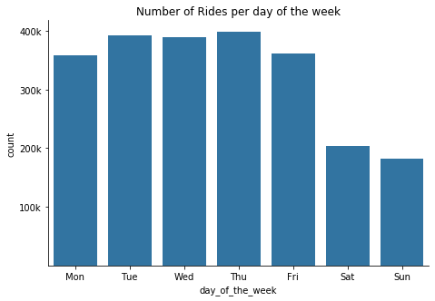

```python
day_of_the_week = ['Mon', 'Tue', 'Wed', 'Thu', 'Fri', 'Sat', 'Sun']
sns.catplot(x="day_of_the_week", kind="count", data=df_bike_clean, color=base_color, order=day_of_the_week, height=4.5,aspect=1.5)
plt.title("Number of Rides per day of the week")
# polishing the plot
plt.yticks([100000, 200000, 300000, 400000], ['100k','200k', '300k','400k']);
```

- Weekdays [Mon-Fri] consists of most of the bike rides
- Thursday is the most popular day for bike rides

#### hourly usage of the bike sharing system

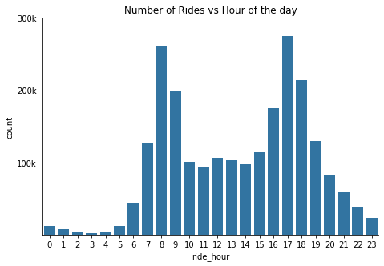

```python
#figure_size(12)
sns.catplot(x="ride_hour", kind="count", data=df_bike_clean, color=base_color,height=4.5,aspect=1.5)
plt.title("Number of Rides vs Hour of the day")
# polishing the plot
plt.yticks([100000, 200000, 300000], ['100k','200k', '300k']);
```

- `Bimodal` distribution can be seen among hours
- Most rides are taken around 8 A.M. and 5 P.M.

#### Monthly Series Analysis - Number of Rides Per Month. Has the business increased over time?

```python
# extract month and year from start time
df_bike_clean['year_m'] = pd.to_datetime(df_bike_clean['start_time']).dt.to_period('M')
df_bike_clean.head(2)
```

|  | duration_sec | start_time | end_time | start_station_name | end_station_name | bike_id | user_type | member_birth_year | member_gender | bike_share_for_all_trip | day_of_the_week | ride_hour | member_age | year_m |
| --- | --- | --- | --- | --- | --- | --- | --- | --- | --- | --- | --- | --- | --- | --- |
| 0 | 75284 | 2018-01-31 22:52:35.239 | 2018-02-01 19:47:19.824 | Mission Dolores Park | Webster St at O'Farrell St | 2765 | Subscriber | 1986 | Male | No | Wed | 22 | 32 | 2018-01 |
| 2 | 71576 | 2018-01-31 14:23:55.889 | 2018-02-01 10:16:52.116 | Jackson St at 5th St | 5th St at Virginia St | 3039 | Customer | 1996 | Male | No | Wed | 14 | 22 | 2018-01 |

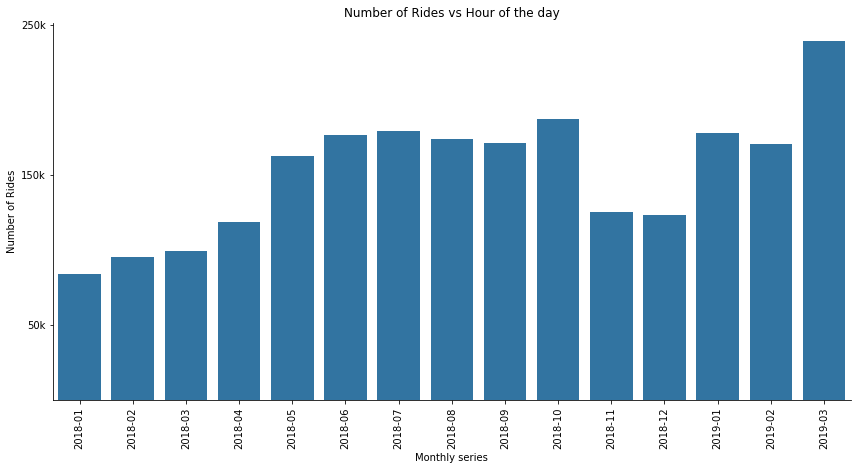

```python
sns.catplot(x="year_m", kind="count", data=df_bike_clean, color=base_color,height=6,aspect=2)
plt.title("Number of Rides vs Hour of the day")
plt.xlabel('Monthly series')
plt.ylabel('Number of Rides')
plt.xticks(rotation = 90)
plt.yticks([50000, 150000, 250000], ['50k','150k','250k']);
```

- Significant increase in the number of rides in the first 3 months of year 2019 as compared to 2018
- Overall average of rides is greater in months from May to Oct, this might be because of pleasant weather

#### Users by gender

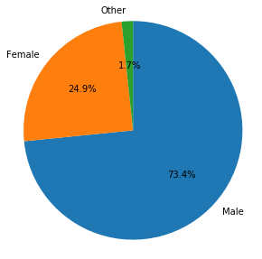

```python
# code for the pie chart
figure_size(12)
sorted_counts = df_bike_clean['member_gender'].value_counts()
plt.pie(sorted_counts, labels = sorted_counts.index, startangle = 90,
        counterclock = False, autopct='%1.1f%%')
plt.axis('square');
```

- Male users are greater in number with approx 73% of the total proportion followed by females with approx 25% prop.

### Discuss the distribution(s) of your variable(s) of interest. Were there any unusual points? Did you need to perform any transformations?

- Male users are approximately thrice than female proportion
- Duration column had some of the very large value (going to 80k).
- Therefore created a function to set a limit to the duration

### Of the features you investigated, were there any unusual distributions? Did you perform any operations on the data to tidy, adjust, or change the form of the data? If so, why did you do this?

- Minimum birth year of some users was less 1900, which did not seem right and it was skewing the data
- So, checked the 95 percentile data for that column, and removed rhe outliers

## 5. Bivariate Exploration

```python
df_bike_clean.head(2)
```

|  | duration_sec | start_time | end_time | start_station_name | end_station_name | bike_id | user_type | member_birth_year | member_gender | bike_share_for_all_trip | day_of_the_week | ride_hour | member_age | year_m |
| --- | --- | --- | --- | --- | --- | --- | --- | --- | --- | --- | --- | --- | --- | --- |
| 0 | 75284 | 2018-01-31 22:52:35.239 | 2018-02-01 19:47:19.824 | Mission Dolores Park | Webster St at O'Farrell St | 2765 | Subscriber | 1986 | Male | No | Wed | 22 | 32 | 2018-01 |
| 2 | 71576 | 2018-01-31 14:23:55.889 | 2018-02-01 10:16:52.116 | Jackson St at 5th St | 5th St at Virginia St | 3039 | Customer | 1996 | Male | No | Wed | 14 | 22 | 2018-01 |

#### At Which hour users are taking longest rides?

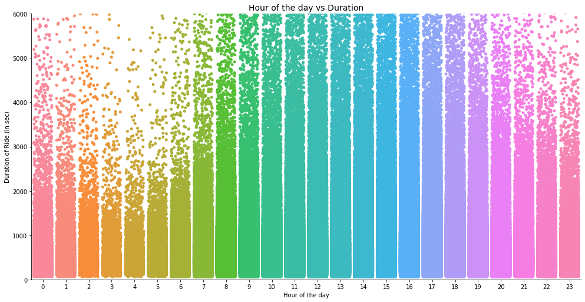

```python
sns.catplot(x="ride_hour", y="duration_sec", data=df_bike_clean, height=7,aspect=2, jitter = .40)
limit_y(6000)
plt.title('Hour of the day vs Duration', fontsize = 14)
plt.xlabel('Hour of the day')
plt.ylabel('Duration of Ride (in sec)');
#plt.yticks([20000,50000, 80000], ['20k','50k','80k']);
```

- As seen previously in univariate analysis, most rides were taken around 8am or 5pm.
- But surprisingly the longest rides are taken around 1 P.M. to 3 P.M.
- Almost seems like people used the bike to go for lunch and came back

#### At What time of the day most bikes were rented on Weekdays vs Weekends?

```python
# differentiating between weekday and weekend
df_bike_clean['week_day_week_end']=df_bike_clean['day_of_the_week'].apply(lambda x: "Weekend" if (x =='Sat' or x =='Sun')
                                                                          else "Weekday")
df_bike_clean.head(2)
```

|  | duration_sec | start_time | end_time | start_station_name | end_station_name | bike_id | user_type | member_birth_year | member_gender | bike_share_for_all_trip | day_of_the_week | ride_hour | member_age | year_m | week_day_week_end |
| --- | --- | --- | --- | --- | --- | --- | --- | --- | --- | --- | --- | --- | --- | --- | --- |
| 0 | 75284 | 2018-01-31 22:52:35.239 | 2018-02-01 19:47:19.824 | Mission Dolores Park | Webster St at O'Farrell St | 2765 | Subscriber | 1986 | Male | No | Wed | 22 | 32 | 2018-01 | Weekday |
| 2 | 71576 | 2018-01-31 14:23:55.889 | 2018-02-01 10:16:52.116 | Jackson St at 5th St | 5th St at Virginia St | 3039 | Customer | 1996 | Male | No | Wed | 14 | 22 | 2018-01 | Weekday |

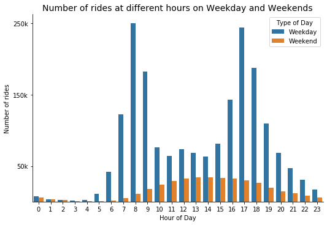

```python
sns.catplot(x="ride_hour", kind="count", data=df_bike_clean,height=5,aspect=1.5, hue = 'week_day_week_end', legend= False)
plt.xlabel("Hour of Day")
plt.ylabel("Number of rides")
plt.title("Number of rides at different hours on Weekday and Weekends", fontsize=14)
plt.legend(title= "Type of Day")
# polishing the plot
plt.yticks([250000,50000, 150000], ['250k','50k','150k']);
```

- As seen in Univariate analysis, the distribution is `bimodal` but through bivariate plot it is clear that bimodal nature is only true for weekdays
- We can add an observation here that the bimodal nature of the hours might be due to the office hours(morning and evening)
- For weekends, it is normally distributed among hours with peak hour around 2 P.M.

#### Which type of user rented bikes on which day?

```python
df_bike_clean.user_type.value_counts()
```

```
Subscriber    2023787
Customer       260695
Name: user_type, dtype: int64
```

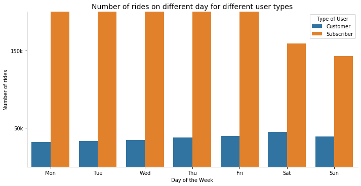

```python
sns.catplot(data=df_bike_clean, x='day_of_the_week', kind='count', hue = 'user_type',height=5, aspect=2,
            order= day_of_the_week, legend = False)
limit_y(200000)
plt.xlabel("Day of the Week")
plt.ylabel("Number of rides")
plt.title("Number of rides on different day for different user types", fontsize=14)
plt.legend(title= "Type of User")
plt.yticks([50000, 150000], ['50k','150k']);
```

- Little hike in number of rides of customers on weekend
- Subscribers have high frequency on weekdays

#### How does ride duration varies with user type?

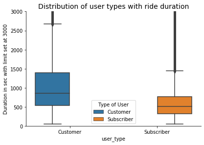

```python
#plot counts by ride_hour on weekday and weekend
sns.catplot(x="user_type",y = 'duration_sec', kind="box", data=df_bike_clean,
            height=4,aspect=1.5, hue = 'user_type', legend= False)
limit_y(3000)
plt.ylabel("Duration in sec with limit set at 3000")
plt.title("Distribution of user types with ride duration", fontsize=14)
plt.legend(title= "Type of User");
# polishing the plot
#plt.yticks([250000,50000, 150000], ['250k','50k','150k']);
```

- `Subsribers` generally have shorter rides than `customers` with median of duration around 500 secs
- `Customers` have median of ride duration around 800 secs

### Talk about some of the relationships you observed in this part of the investigation. How did the feature(s) of interest vary with other features in the dataset?

- `Customers` on weekend take more rides and can be termed as temporary users, on the other hand `Subscribers` have high frequency on weekdays and can be termed as permanent users
- `Subsribers` generally have shorter rides than `Customers` with median of duration around 500 secs
- `Customers` have median of ride duration around 800 secs

### Did you observe any interesting relationships between the other features (not the main feature(s) of interest)?

- The `longest rides`(duration_sec) are taken around 1 P.M. to 3 P.M.(ride_hour)
- `bimodal` nature of hours vs number of rides is only true for weekdays

```python
df_bike_clean = df_bike_clean.reset_index()
df_bike_clean.head()
```

|  | index | duration_sec | start_time | end_time | start_station_name | end_station_name | bike_id | user_type | member_birth_year | member_gender | bike_share_for_all_trip | day_of_the_week | ride_hour | member_age | year_m | week_day_week_end |
| --- | --- | --- | --- | --- | --- | --- | --- | --- | --- | --- | --- | --- | --- | --- | --- | --- |
| 0 | 0 | 75284 | 2018-01-31 22:52:35.239 | 2018-02-01 19:47:19.824 | Mission Dolores Park | Webster St at O'Farrell St | 2765 | Subscriber | 1986 | Male | No | Wed | 22 | 32 | 2018-01 | Weekday |
| 1 | 2 | 71576 | 2018-01-31 14:23:55.889 | 2018-02-01 10:16:52.116 | Jackson St at 5th St | 5th St at Virginia St | 3039 | Customer | 1996 | Male | No | Wed | 14 | 22 | 2018-01 | Weekday |
| 2 | 4 | 39966 | 2018-01-31 19:52:24.667 | 2018-02-01 06:58:31.053 | Laguna St at Hayes St | Post St at Kearny St | 617 | Subscriber | 1991 | Male | No | Wed | 19 | 27 | 2018-01 | Weekday |
| 3 | 6 | 453 | 2018-01-31 23:53:53.632 | 2018-02-01 00:01:26.805 | 17th & Folsom Street Park (17th St at Folsom St) | Valencia St at 24th St | 3571 | Subscriber | 1988 | Male | No | Wed | 23 | 30 | 2018-01 | Weekday |
| 4 | 7 | 180 | 2018-01-31 23:52:09.903 | 2018-01-31 23:55:10.807 | Berry St at 4th St | 4th St at Mission Bay Blvd S | 1403 | Subscriber | 1980 | Male | No | Wed | 23 | 38 | 2018-01 | Weekday |

## 6. Multivariate Exploration

```python
df_bike_clean=df_bike_clean.astype({'bike_id': 'int32'})
```

```python
df_bike_clean.info()
```

```
<class 'pandas.core.frame.DataFrame'>
RangeIndex: 2284482 entries, 0 to 2284481
Data columns (total 16 columns):
index                      int64
duration_sec               int64
start_time                 datetime64[ns]
end_time                   datetime64[ns]
start_station_name         object
end_station_name           object
bike_id                    int32
user_type                  category
member_birth_year          int32
member_gender              category
bike_share_for_all_trip    category
day_of_the_week            object
ride_hour                  int64
member_age                 int32
year_m                     period[M]
week_day_week_end          object
dtypes: category(3), datetime64[ns](2), int32(3), int64(3), object(4), period[M](1)
memory usage: 207.0+ MB
```

#### Which gender has taken longer rides in different age groups?

```python
# creating bins from age column
df_bike_clean['age_bins'] = df_bike_clean['member_age'].apply(lambda x: '10 - 20' if 10<x<=20
                                                  else '20 - 30' if 20<x<=30
                                                  else '30 - 40' if 30<x<=40
                                                  else '40 - 50' if 40<x<=50
                                                  else '50 - 60' if 50<x<=60
                                                  else x)
age_order = ['10 - 20','20 - 30', '30 - 40', '40 - 50', '50 - 60']
```

```python
df_try= df_bike_clean.sample(10000)
```

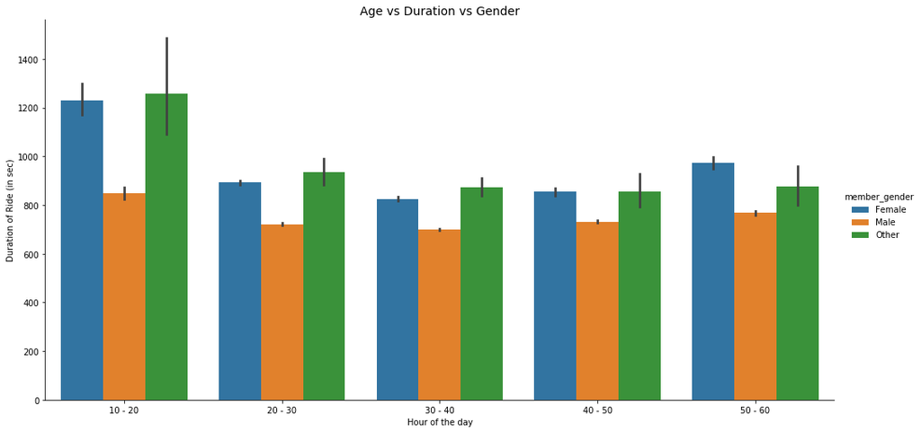

```python
sns.catplot(x= "age_bins", y= "duration_sec", hue="member_gender", kind="bar", data=df_bike_clean, order = age_order,
           height = 7, aspect = 2)
plt.title('Age vs Duration vs Gender', fontsize = 14)
plt.xlabel('Hour of the day')
plt.ylabel('Duration of Ride (in sec)');
#plt.yticks([20000,50000, 80000], ['20k','50k','80k']);
```

- Users in the 10-20 age range have the longest trips to their name
- Genders marked as `other` generally have taken longer trips, but as seen previously their proportion is just 1.7% of the total data (too much variance)
- Females have taken significant longer trips than males among age groups 10-20 and 50-60
- Females in the age group 50-60 have the longer trips

#### Number of rides for which a user shared ride among different User type

```python
df_bike_clean.info()
```

```
<class 'pandas.core.frame.DataFrame'>
RangeIndex: 2284482 entries, 0 to 2284481
Data columns (total 17 columns):
index                      int64
duration_sec               int64
start_time                 datetime64[ns]
end_time                   datetime64[ns]
start_station_name         object
end_station_name           object
bike_id                    int32
user_type                  category
member_birth_year          int32
member_gender              category
bike_share_for_all_trip    category
day_of_the_week            object
ride_hour                  int64
member_age                 int32
year_m                     period[M]
week_day_week_end          object
age_bins                   object
dtypes: category(3), datetime64[ns](2), int32(3), int64(3), object(5), period[M](1)
memory usage: 224.4+ MB
```

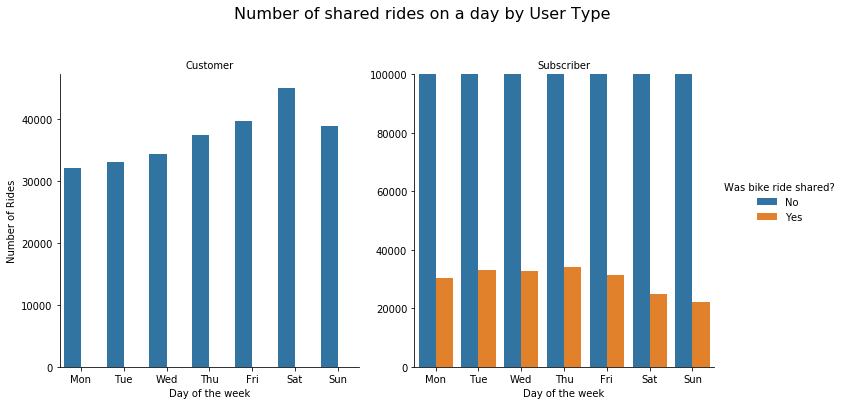

```python
g = sns.catplot(data=df_bike_clean, x='day_of_the_week', col="user_type", hue='bike_share_for_all_trip',
            kind='count',order = day_of_the_week , sharey= False, legend=True)
limit_y(100000)
plt.suptitle('Number of shared rides on a day by User Type', size=16, y=1.12)
g.set_titles("{col_name}")
g._legend.set_title('Was bike ride shared?')
g.set_axis_labels("Day of the week", "Number of Rides");
#plt.yticks([20000,50000, 80000], ['20k','50k','80k']);
```

- Customers have `never` shared a ride
- Subscribers have a constant number of shared rides on weekdays, a little drop on weekends

#### Trip duration on the basis of user type and member gender

```python
df_try.info()
```

```
<class 'pandas.core.frame.DataFrame'>
Int64Index: 10000 entries, 1556345 to 1349620
Data columns (total 17 columns):
index                      10000 non-null int64
duration_sec               10000 non-null int64
start_time                 10000 non-null datetime64[ns]
end_time                   10000 non-null datetime64[ns]
start_station_name         10000 non-null object
end_station_name           10000 non-null object
bike_id                    10000 non-null int32
user_type                  10000 non-null category
member_birth_year          10000 non-null int32
member_gender              10000 non-null category
bike_share_for_all_trip    10000 non-null category
day_of_the_week            10000 non-null object
ride_hour                  10000 non-null int64
member_age                 10000 non-null int32
year_m                     10000 non-null period[M]
week_day_week_end          10000 non-null object
age_bins                   10000 non-null object
dtypes: category(3), datetime64[ns](2), int32(3), int64(3), object(5), period[M](1)
memory usage: 1.1+ MB
```

```python
top3 = df_bike_clean.start_station_name.value_counts().index[:3]
top3
```

```
Index(['San Francisco Caltrain Station 2  (Townsend St at 4th St)',
       'Market St at 10th St', 'Berry St at 4th St'],
      dtype='object')
```

```python
df_top3 = df_bike_clean.query('start_station_name in ("Berry St at 4th St","Market St at 10th St","San Francisco Caltrain Station 2  (Townsend St at 4th St)")')
df_top3.shape
```

```
(132678, 17)
```

```python
df_top3['start_station'] = df_top3['start_station_name'].replace({'San Francisco Caltrain Station 2  (Townsend St at 4th St)': 'SF Caltrain St 2'})
```

```python
df_top3.sample(5)
```

|  | index | duration_sec | start_time | end_time | start_station_name | end_station_name | bike_id | user_type | member_birth_year | member_gender | bike_share_for_all_trip | day_of_the_week | ride_hour | member_age | year_m | week_day_week_end | age_bins | start_station |
| --- | --- | --- | --- | --- | --- | --- | --- | --- | --- | --- | --- | --- | --- | --- | --- | --- | --- | --- |
| 413765 | 18495 | 817 | 2018-05-29 09:47:20.594 | 2018-05-29 10:00:57.624 | Berry St at 4th St | Clay St at Battery St | 482 | Subscriber | 1985 | Male | No | Tue | 9 | 33 | 2018-05 | Weekday | 30 - 40 | Berry St at 4th St |
| 1985021 | 118539 | 555 | 2019-02-11 18:45:38.650 | 2019-02-11 18:54:54.364 | San Francisco Caltrain Station 2 (Townsend St... | Powell St BART Station (Market St at 5th St) | 4963 | Subscriber | 1984 | Male | No | Mon | 18 | 35 | 2019-02 | Weekday | 30 - 40 | SF Caltrain St 2 |
| 452448 | 61496 | 669 | 2018-05-21 11:50:15.708 | 2018-05-21 12:01:25.384 | Berry St at 4th St | Victoria Manalo Draves Park | 3029 | Subscriber | 1985 | Female | No | Mon | 11 | 33 | 2018-05 | Weekday | 30 - 40 | Berry St at 4th St |
| 770147 | 37858 | 705 | 2018-07-25 20:20:59.428 | 2018-07-25 20:32:44.811 | Berry St at 4th St | Clay St at Battery St | 1759 | Subscriber | 1991 | Male | No | Wed | 20 | 27 | 2018-07 | Weekday | 20 - 30 | Berry St at 4th St |
| 183570 | 5481 | 585 | 2018-03-30 12:21:01.813 | 2018-03-30 12:30:46.940 | Market St at 10th St | Valencia St at 16th St | 1919 | Subscriber | 1990 | Female | No | Fri | 12 | 28 | 2018-03 | Weekday | 20 - 30 | Market St at 10th St |

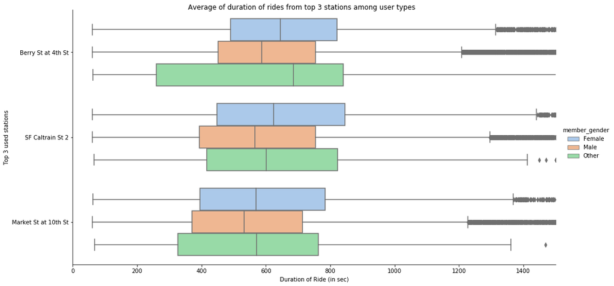

```python
sns.catplot(y="start_station",x = 'duration_sec',hue = 'member_gender',
            kind="box",data=df_top3, height=7, aspect = 2, palette= 'pastel')
plt.suptitle('Average of duration of rides from top 3 stations among user types', size=12, y =1)
plt.ylabel('Top 3 used stations')
plt.xlabel('Duration of Ride (in sec)');
limit_x(1500);
```

- Males take shorter rides on an average
- Females take longer bike rides from most used station `San Francisco Caltrain St2`